# Unsupervised Learning – Principal Component Analysis

Daniel Bauer

As mentioned, there are (at least) two basic learning setups. In **supervised** machine learning one observes a response $Y$ with observing $p$ different features $X=(X_1,X_2,\ldots,X_p)$, where we typically postulate the relationship $Y = f(X)+\varepsilon$ and $\varepsilon$ independent of $X$ with mean zero. Here quality is usually assessed by the (test/out-of-sample) error that compares predictions and realizations for a separate dataset. In **unsupervised** learning, we only observe $p$ features $X_1,X_2,\ldots,X_p$, and we would like to learn about their relationship – without focussing on a supervising outcome. Of course, the difficulty is how to assess quality in this case – so different unsupervised learning techniques are very different, and which one to pick will depend on the nature of the problem.

In this tutorial, we will take a closer look at one key unsupervised learning approach: **Principal Component Analysis (PCA)**. There are variety of other techniques, including clustering (covered next), anomaly detection, self-organizing maps, association analysis, etc.

## Clear the slate and install required packages

# Principal Component Analysis

## Background

The key idea behind *Principal Component Analysis* (PCA) is to use “meaningful” linear combinations of the data:
$$Z_m = \sum_{j=1}^p \phi_{jm} X_j \text{ such that }\sum_{j=1}^p \phi^2_{jm} = 1,$$
where the idea is to choose:

- $\phi_{j1},\,j=1,\ldots,p$ such that the the variance of $Z_1$ is maximal (i.e., so that it captures most of the variation in the $X$s)
- $\phi_{j2},\,j=1,\ldots,p$ such that the variance of $Z_2$ is maximial out of all the variables that are uncorrelated with $Z_1$.
- $\phi_{j3},\,j=1,\ldots,p$ such that the variance of $Z_3$ is maximial out of all the variables that are uncorrelated with $Z_1$ and $Z_2$. $\ldots$

Hence, one way to intepret the principal components are the linear combination that best reflect the variation in the data.

Importantly, the scale of variables matters, so it is a good idea to center and scale your variables. Also, the components are only determined up to their sign (plus/minus). To discern how important different variables are, one typically considers the *Percent of Variance Explained* (PVE):
$$\text{PVE}_m = \frac{\sum_{i=1}^n \left(\sum_{j=1}^p \phi_{jm}x_{ij}\right)^2}{\sum_{i=1}^n \sum_{j=1}^p x_{ij}^2},$$
and the resulting plot that depicts PVE by principal components is referred to as a *scee plot*.

## Simulated Example

```r
library(mvtnorm)
nsim <- 5000
set.seed(123)
mu <- c(66,170)                 # mean height, weight
s2 <- c(9, 400)
rho <- 0.5
cov <- rho * s2[1]^.5 * s2[2]^.5
sigma <- matrix(c(s2[1],cov,cov,s2[2]), ncol=2);
sigma
```

```
     [,1] [,2]
[1,]    9   30
[2,]   30  400
```

```r
X.raw <- rmvnorm(nsim, mean=mu, sigma=sigma)
colMeans(X.raw)
```

```
[1]  66.0078 169.7134
```

```r
cov(X.raw)
```

```
          [,1]     [,2]
[1,]  8.873754  28.9928
[2,] 28.992805 397.2249
```

```r
cor(X.raw)
```

```
          [,1]      [,2]
[1,] 1.0000000 0.4883355
[2,] 0.4883355 1.0000000
```

So the *empirical* moments look similar to our theoretical moments. Let’s take a peak:

```r
plot(X.raw, xlab="Height", ylab="Weight")
title("Height, Weight Data", col.main="navy")
abline(v=mean(X.raw[,1]), col="blue", lwd=1)
abline(h=mean(X.raw[,2]), col="blue", lwd=1)
rho <- round(cor(X.raw)[1,2], 3); rho
```

```
[1] 0.488
```

```r
txt <- paste("rho =", rho)
text(58, 230, txt, col="red", cex=1.5)
library(psych)
```

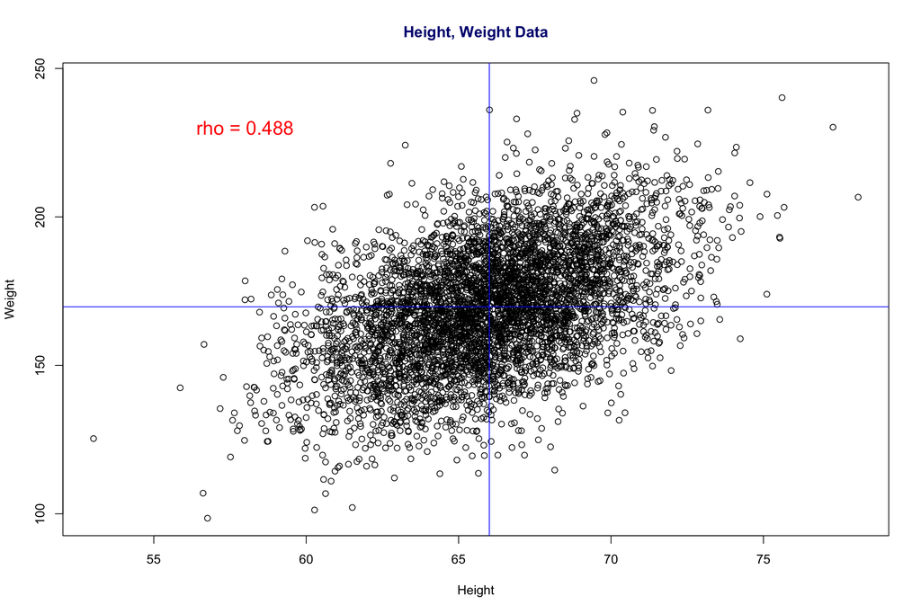

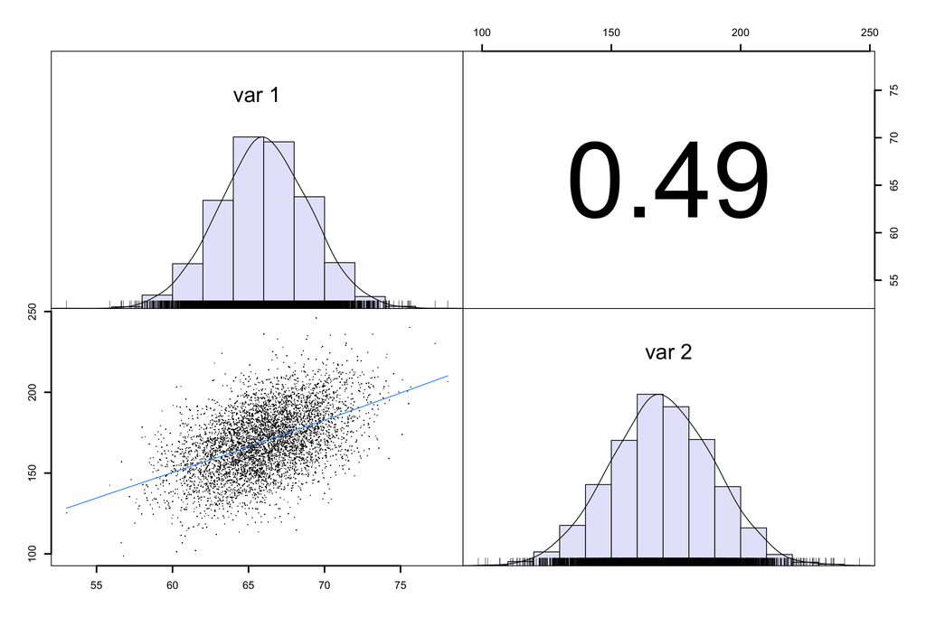

```r
pairs.panels(X.raw, gap=0, ellipses=F, pch=".", hist.col='lavender', col="dodgerblue", lwd=2)
```

Prinicipal components are closely related to the eigen-analysis (eigenvalues and eigenvectors) of the correlation (or covariance) matrix. Let’s illustrate (if you never had a linear algebra class, feel free to skip this part). First, let’s scale the data and calculate the (empirical) correlation matrix – remember, in practical settings we usually don’t know the underlying parameters:

```r
X <- scale(X.raw)
R <- cor(X); R
```

```
          [,1]      [,2]
[1,] 1.0000000 0.4883355
[2,] 0.4883355 1.0000000
```

Let’s calculate the eigenvalues and the eigenvectors of `R`. As a reminder, the eigenvectors decompose a matrix (a.k.a. a linear mapping in finite dimensions) in orthogonal directions, whereas the eignvalues provide the “length” (importance) of the directions. In particular, we can represent a symmetric matrix in diagnolized form by relying on eigenvectors and eigenvalues. Note that vector/matrix multiplication in `R` is denoted by `%*%`, whereas `*` does component-wise multiplication:

```r
eig <- eigen(R)
V <- eig$vector; V
```

```
          [,1]       [,2]
[1,] 0.7071068 -0.7071068
[2,] 0.7071068  0.7071068
```

```r
L <- eig$value; L
```

```
[1] 1.4883355 0.5116645
```

```r
V %*% diag(L) %*% t(V)
```

```
          [,1]      [,2]
[1,] 1.0000000 0.4883355
[2,] 0.4883355 1.0000000
```

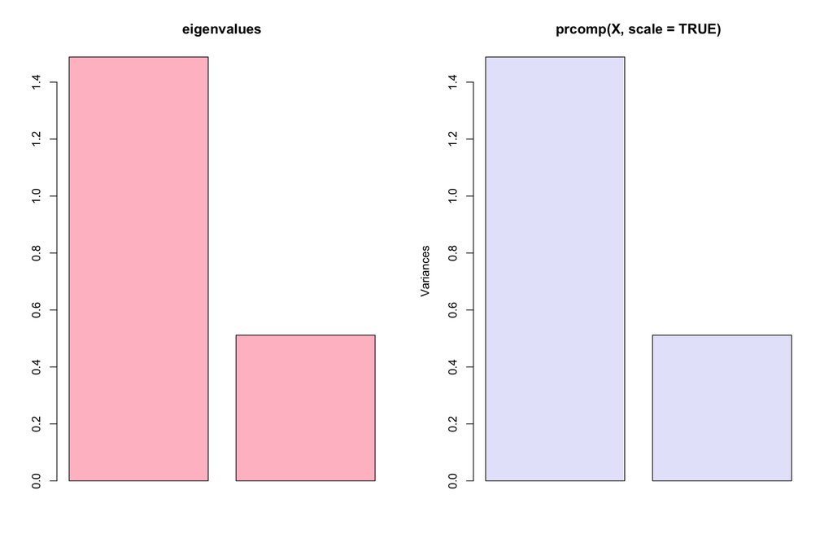

```r
par(mfrow=c(1,2))
barplot(L, col="pink", main="eigenvalues")
plot(prcomp(X, scale=TRUE), col='lavender')
```

…and the principal’s rotations are simply the corresponding eigenvectors:

```r
V
```

```
          [,1]       [,2]
[1,] 0.7071068 -0.7071068
[2,] 0.7071068  0.7071068
```

```r
prcomp(X, scale=TRUE)$rotation
```

```
           PC1        PC2
[1,] 0.7071068 -0.7071068
[2,] 0.7071068  0.7071068
```

To get the principal components $Z$ from above, we simply use the linear combinations of the data according to eigenvalues/rotations:

```r
pc.1 <- V[1,1]*X[,1] + V[2,1]*X[,2]
pc.2 <- V[1,2]*X[,1] + V[2,2]*X[,2]
cor(pc.1, pc.2)
```

```
[1] 5.119105e-17
```

```r
var(pc.1); var(pc.2)
```

```
[1] 1.488336
```

```
[1] 0.5116645
```

```r
L
```

```
[1] 1.4883355 0.5116645
```

So the first principal component is simply the linear combination of the data according to the eigenvector, and its variance coincides with the first eigenvalue – which of course is greater than the second eigenvalue. And the same for the second principal component.

More compactly, we could use matrix algebra for the derivation:

```r
PC <- X %*% V
cor(PC)
```

```
             [,1]         [,2]
[1,] 1.000000e+00 5.119105e-17
[2,] 5.119105e-17 1.000000e+00
```

```r
var(PC)
```

```
             [,1]         [,2]
[1,] 1.488336e+00 4.467217e-17
[2,] 4.467217e-17 5.116645e-01
```

```r
lambda <- diag(var(PC))
lambda; L
```

```
[1] 1.4883355 0.5116645
```

```
[1] 1.4883355 0.5116645
```

```r
sum(lambda)
```

```
[1] 2
```

```r
lambda / sum(lambda)
```

```
[1] 0.7441678 0.2558322
```

To get intuition, let’s plot the PCs:

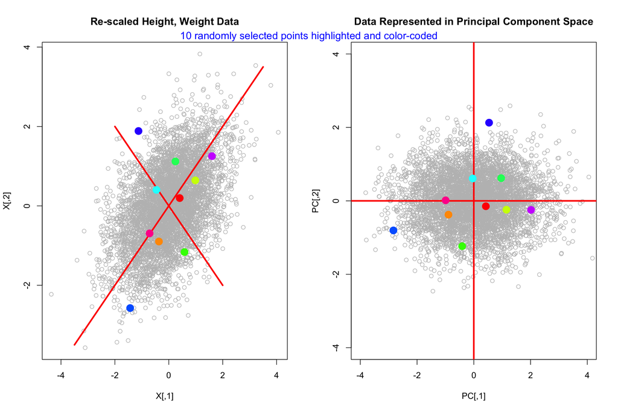

```r
par(mfrow=c(1,2))
plot(X, col="grey", main="Re-scaled Height, Weight Data")
segments(-3.5,-3.5,3.5,3.5, col="red", lwd=3)
segments(-2,2,2,-2, col="red", lwd=3)

col <- rainbow(10)
set.seed(1)
keep <- sample(1:nrow(X), 10, replace=FALSE)
points(X[keep,], col=col, pch=16, cex=2)

plot(PC, col="grey", xlim=c(-4,4), ylim=c(-4,4)
    , main="Data Represented in Principal Component Space")
abline(h=0, col="red", lwd=3)
abline(v=0, col="red", lwd=3)
points(PC[keep,], col=col, pch=16, cex=2)
txt <- "10 randomly selected points highlighted and color-coded"
mtext(txt, outer=T, col="blue", line=-4, cex=1.2)
```

So the principal component weights just give the most important dimensions in the data, with the length corresponding to their importance (i.e., the eigenvalues). If we rotate accordingly, the data just looks like independent noise.